# FirmScope Analytics: From 12 Raw KPIs to 3 Business-Health Factors

## 1.4 0.4 Correlation Heatmap of the Standardized KPIs — Why We Need Factor Analysis

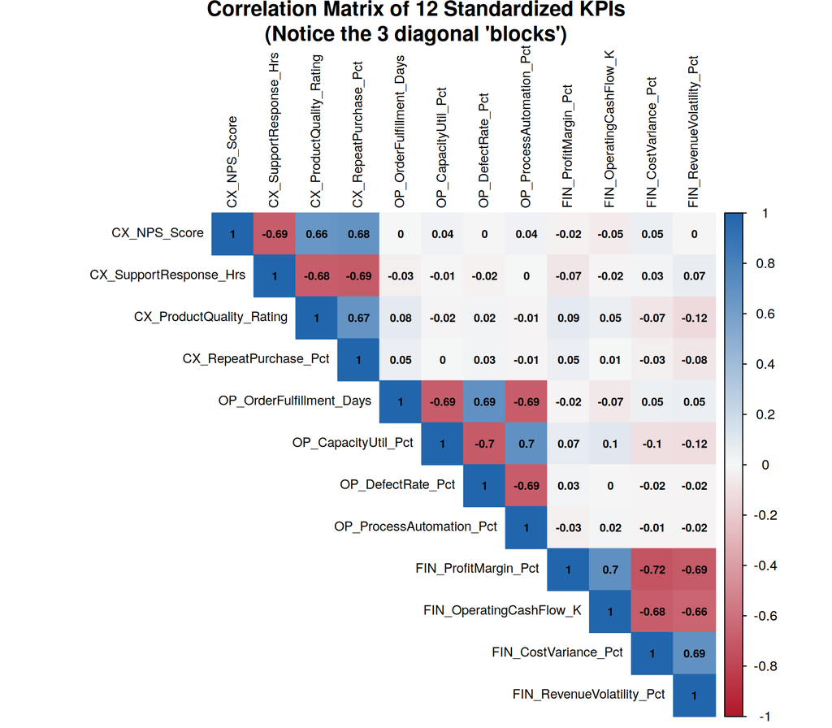

```r
# ---------------------------------------------------------------------------
# WHAT: Visualize the correlation matrix of all 12 standardized KPIs.
# WHY:  This is the single most important diagnostic chart in Stage 0. It
#       will reveal a "block" structure: KPIs from the same business domain
#       (CX, OP, FIN) are strongly correlated with each other (|r| ~ 0.6-0.8),
#       while KPIs from DIFFERENT domains are nearly uncorrelated (|r| ~ 0).
#       That block pattern is exactly the signature of redundant proxies
#       measuring the same underlying construct -- and it is exactly the
#       problem Factor Analysis is designed to solve.
# ---------------------------------------------------------------------------
raw_cor <- cor(kpi_scaled_df)

corrplot(raw_cor, method = "color", type = "upper", order = "original",
         addCoef.col = "black", number.cex = 0.65, tl.cex = 0.75, tl.col = "black",
         col = colorRampPalette(c("#B2182B", "#F7F7F7", "#2166AC"))(200),
         title = "Correlation Matrix of 12 Standardized KPIs\n(Notice the 3 diagonal 'blocks')",
         mar = c(0, 0, 2, 0))
```

**Reading this chart:** trace the diagonal and you’ll see three distinct clusters of dark color — the four `CX_*` KPIs correlate strongly with each other, the four `OP_*` KPIs correlate strongly with each other, and the four `FIN_*` KPIs correlate strongly with each other. Off-block, the correlations are close to zero. In other words: **within** each domain we have redundant information (multicollinearity), but **across** domains the KPIs are genuinely independent. This is precisely the pattern Factor Analysis is built to compress: 12 redundant columns → 3 clean, independent business-health scores.

## 1.5 0.5 Is the Data Suitable for Factor Analysis? KMO and Bartlett’s Test

```r
# ---------------------------------------------------------------------------
# WHAT: Run two formal statistical checks before committing to Factor Analysis.
#
#   1) KMO (Kaiser-Meyer-Olkin) Measure of Sampling Adequacy: checks whether
#      the correlations between variables are strong enough, relative to
#      noise, to be worth factoring. Rule of thumb: KMO > 0.6 is acceptable,
#      > 0.8 is "meritorious," > 0.9 is "marvelous."
#
#   2) Bartlett's Test of Sphericity: tests the null hypothesis that the
#      correlation matrix is just an identity matrix (i.e., all variables are
#      unrelated, so there is NOTHING for Factor Analysis to extract). We
#      WANT to reject this null hypothesis with a very small p-value --
#      that tells us the variables are related enough to justify factoring.
# ---------------------------------------------------------------------------
kmo_result <- KMO(kpi_scaled_df)
cat("Overall KMO (Measure of Sampling Adequacy):", round(kmo_result$MSA, 3), "\n\n")
```

```
## Overall KMO (Measure of Sampling Adequacy): 0.845
```

```r
bartlett_result <- cortest.bartlett(raw_cor, n = nrow(kpi_scaled_df))
cat("Bartlett's Test of Sphericity:\n")
```

```
## Bartlett's Test of Sphericity:
```

```r
cat("  Chi-square =", round(bartlett_result$chisq, 1),
    " | df =", bartlett_result$df,
    " | p-value =", format.pval(bartlett_result$p.value, digits = 3), "\n")
```

```
##   Chi-square = 3589.3  | df = 66  | p-value = <2e-16
```

**Verdict for MBA students:** our overall KMO is **0.84**, which falls in the “meritorious” range (well above the 0.6 minimum) — the KPIs share enough common variance to make Factor Analysis worthwhile. Bartlett’s test comes back with a p-value essentially at zero, so we confidently reject the idea that these 12 KPIs are unrelated noise. **Both diagnostics give Factor Analysis a green light.**

# 2 Stage 1 — Factor Analysis: Compressing 12 KPIs into 3 Business-Health Factors

## 2.1 1.1 How Many Factors Should We Extract? Scree Plot + Parallel Analysis

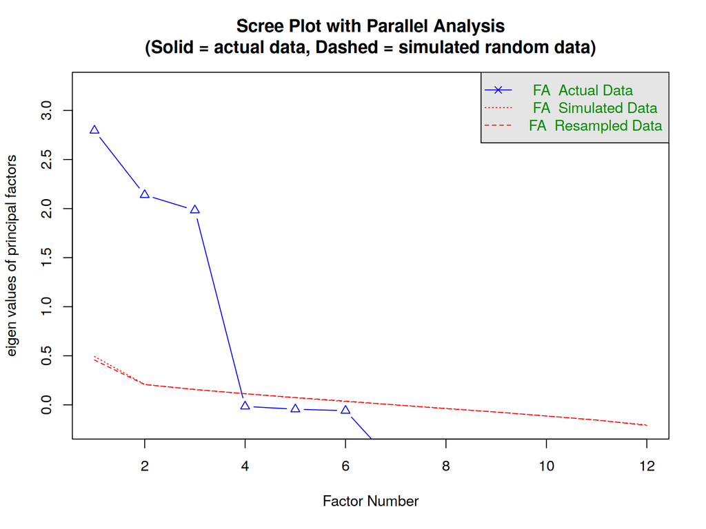

```
## Parallel analysis suggests that the number of factors =  3  and the number of components =  NA
```

```r
# ---------------------------------------------------------------------------
# WHAT: Run a Scree Plot alongside Horn's Parallel Analysis to decide how
#       many factors to retain.
# WHY:  A Scree Plot shows how much variance each successive factor explains
#       -- we look for the "elbow" where the curve flattens out. But eyeballing
#       an elbow is subjective. Parallel Analysis makes the decision objective:
#       it simulates many random datasets with the SAME number of variables
#       and observations (but no real correlation structure), and compares
#       our REAL eigenvalues against the eigenvalues we'd expect from pure
#       noise. We only keep factors whose real eigenvalue beats the
#       random-noise eigenvalue.
# ---------------------------------------------------------------------------
parallel_analysis <- fa.parallel(kpi_scaled_df, fa = "fa", n.iter = 100,
                                  main = "Scree Plot with Parallel Analysis\n(Solid = actual data, Dashed = simulated random data)",
                                  show.legend = TRUE)
```

```r
cat("Parallel Analysis suggests retaining", parallel_analysis$nfact, "factor(s).\n")
```

```
## Parallel Analysis suggests retaining 3 factor(s).
```

Parallel Analysis confirms **3 factors** — exactly matching FirmScope’s three business domains (Customer Experience, Operational Efficiency, Financial Health). This gives us a statistically grounded reason (not just a business hunch) to extract 3 factors in the next step.